# Project2

2022-10-23

```r
LaLiga <- read.csv2("~/Big 5 European football leagues teams stats.csv")
EPL <- read.csv2("~/EPL Standings 2000-2022.csv")
Bundesliga <- read.csv2("~/Bundesliga Points Table (2013-2018).csv")
```

### Arham Salman, Kevin Dang, Malik Hamed

## Title & Introduction

**Analysis of soccer Team Statistics across Major European Soccer Leagues**

**Our group decided to compare different European soccer leagues and tournaments to determine which team is the best in the world. We wanted to use Soccer statistics for our project because we enjoy the sport and want to figure out which team is the best in the world. We chose datasets from Kaggle as they had relevant data from teams in the seasons from 2013-2018. These sources were interesting because they were all similarly formatted, and show the proper statistics that measure a team’s success. Each unique row in the datasets represent the team name (categorical variable), matches played (numeric variable), goals scored (numeric), wins & losses (numeric), and rank finished (numeric). The sources used for this project are cited below: https://www.kaggle.com/datasets/jehanbhathena/big-5-european-football-leagues-stats https://www.kaggle.com/datasets/suwadith/europes-top-5-league-tables-2009-2018 https://www.kaggle.com/datasets/quadeer15sh/premier-league-standings-11-seasons-20102021**

## Tidying

**Our group did not have to do any tidying for this project. All of our data obtained had proper variables and did not have observations as columns.**

## Joining & Merging

```r
#The following chunk of code renames each dataset exported from Kaggle to make data easier to analyze and save the import. (Arham)
Bundesliga <- read.csv("~/Bundesliga Points Table (2013-2018).csv", header = TRUE)
EPL <- read.csv("~/EPL Standings 2000-2022.csv", header = TRUE)
LaLiga <- read.csv("~/Big 5 European football leagues teams stats.csv", header = TRUE)
```

We mutated and filtered the datasets so that they all have the same name for certain variables we will join them by later.

```r
#changes variable names to a standard for joining later for all three leagues. (Arham)
LaLiga <- LaLiga %>%
  filter(League == "La Liga") %>%
  mutate(Year = season, Team = squad, Rank = rank, Games = games, Wins = wins, Draws = draws, Losses = losses, Points = points, GoalsFor = goals_for, GoalsAgainst = goals_against)


Bundesliga <- Bundesliga %>%
  mutate(Games = Played, Wins = Win, Draws = Draw, Losses = Loss, GoalsFor = Goals.For, GoalsAgainst = Goals.Against) %>%
  drop_na(Rank)

EPL <- EPL %>%
  mutate(Year = Season, Rank = Pos, Games = Pld, Wins = W, Draws = D, Losses = L, Points = Pts,GoalsFor = GF, GoalsAgainst = GA)
```

**For the LaLiga dataset, we filtered out the league “LaLiga” from the Big 5 European football league teams stats dataset to only include one league for future analyses.**

Then, we used full join to combine the three datasets into one big dataset that contains all the important observations from the other datasets under key variables

```r
#first join function to join the leagues La Liga and Premier League. (Malik)


Join2 <- LaLiga %>%
  full_join(EPL, by = c("Rank", "Team", "Games", "Wins", "Year", "Draws", "Losses", "Points","GoalsFor", "GoalsAgainst", "League"))

#second join function which joins the previous dataset to the Bundesliga league (Malik)

BigDataset <- Join2 %>%
  full_join(Bundesliga, by = c("Team", "Rank", "Games", "Wins", "Year", "Draws", "Losses", "Points", "GoalsFor","GoalsAgainst", "League"))
```

Next, we found out the total number of observations in our big dataset.

```r
# counts the number of observations in each dataset (Kevin)
count(LaLiga)
```

```
##     n
## 1 220
```

```r
count(EPL)
```

```
##     n
## 1 440
```

```r
count(Bundesliga)
```

```
##    n
## 1 90
```

```r
#finds number of unique IDs in each dataset (Kevin)
ncol(LaLiga)
```

```
## [1] 38
```

```r
ncol(EPL)
```

```
## [1] 21
```

```r
ncol(Bundesliga)
```

```
## [1] 18
```

**There are 38 unique IDs in the LaLiga dataset, 21 in the EPL dataset, and 18 in the Bundesliga dataset.**

Next, we found which IDs were in a certain dataset and not in others.

We then found the IDs in common in all the dataset.

**The IDs we found in common in all datasets were Team, Rank, Wins, Losses, GoalsFor, GoalsAgainst, Year, Games, Points, Draws, and League. We will be selecting these variables later for wrangling. The IDs we decided to exclude were the extra variables in LaLiga but not the other 2 datasets (notes, players_used, assists, pens_made, pens_att, cards_yellow, cards_red, shots_on_target_against, saves, clean_sheets, shots_on_target, game_starts, games_complete, games_subs, unused_subs, and points_per_match).**

Lastly, we counted how many observations we excluded from each dataset.

**We excluded all the NA observations in the Bundesliga dataset, reducing the number of observations from 180 to 90. Then, we excluded the other 4 leagues from the Big 5 European football leagues team stats to only show stats from LaLiga and went from 1078 observations to 220.**

## Data Wrangling

The combined Dataset we made with the three separate datasets was untidy as it contained many irrelevant variables and NA values. We created a new dataset based off the big dataset which only selects the variables we joined the three datasets by.

```r
#selects the variables we are interested in observing. (Arham)

BigDatasetFinal <- BigDataset %>%
  select(Team, Rank, Wins, Losses, GoalsFor, GoalsAgainst, Year, Games, Points, Draws, League) %>%
  filter(Year > 2013 & Year < 2018) %>%
  arrange(Year, League) %>%
  group_by(Team, Wins)
```

The fist analysis we conducted shows how many total teams we have in this dataset.

```r
#calculates total number of teams in the dataset. (Arham)

length(table(BigDatasetFinal$Team))
```

```
## [1] 79
```

**We found that there are a total of 79 distinct teams in this dataset. These teams represent the highest quality of soccer in the world as their leagues are the most popular and successful.**

We then figured out how many teams there are in each league to see if there is a disparity in sample size that we should be aware of.

```r
#creates tibble to portray the number of teams per league; https://www.statology.org/dplyr-count-distinct/ (Malik)

BigDatasetFinal %>%
  group_by(League) %>%
  summarize(n = n_distinct(Team))
```

```
## # A tibble: 3 × 2
##   League             n
##   <chr>          <int>
## 1 Bundesliga        23
## 2 La Liga           28
## 3 Premier League    28
```

Next, we determined which team had the most wins during our 5 year study range (2013-2018).

```r
# finds which team had the most wins during the 5 year study range. (Malik)

BigDatasetFinal %>%
  group_by(League, Team) %>%
  summarize(Freq = sum(Wins)) %>%
  arrange(desc(Freq))
```

```
## # A tibble: 79 × 3
## # Groups:   League [3]
##    League         Team               Freq
##    <chr>          <chr>             <int>
##  1 La Liga        Barcelona           142
##  2 La Liga        Real Madrid         136
##  3 Bundesliga     Bayern Munich       134
##  4 La Liga        Atlético Madrid     125
##  5 Premier League Manchester City     125
##  6 Premier League Chelsea             114
##  7 Premier League Arsenal             108
##  8 Premier League Tottenham Hotspur   108
##  9 Premier League Liverpool           103
## 10 Premier League Manchester United   101
## # … with 69 more rows
```

**After running dplyr functions to find the team with the most wins, we found that Barcelona, from La Liga, had the most wins, with 142, during our 5 year study range from 2013-2018.**

The next analysis we conducted was to determine offensive effeciency for each team in our study. We looked at the total number of goals each team scored in the 5 year span.

```r
# finds total number of goals scored by each team. (Kevin)

BigDatasetFinal %>%
  group_by(League, Team) %>%
  summarize(Goals = sum(GoalsFor)) %>%
  arrange(desc(Goals))
```

```
## # A tibble: 79 × 3
## # Groups:   League [3]
##    League         Team              Goals
##    <chr>          <chr>             <int>
##  1 La Liga        Barcelona           537
##  2 La Liga        Real Madrid         532
##  3 Premier League Manchester City     442
##  4 Bundesliga     Bayern Munich       435
##  5 Premier League Liverpool           378
##  6 Premier League Arsenal             355
##  7 Premier League Chelsea             350
##  8 Bundesliga     Borussia Dortmund   345
##  9 Premier League Tottenham Hotspur   342
## 10 La Liga        Atlético Madrid     335
## # … with 69 more rows
```

**Using similar code used for the previous summary statistics, we determined that Barcelona scored the most goals in the timespan of 2013-2018 with a total of 537 goals.**

To determine which team was the most dominant during the years 2013-2018, we decided that finding how they placed compared to their competition (League) would be the best way to establish their dominance. We did this by looking at which teams consistently finished with the highest ranks during the 5 year study span.

```r
#filters all the teams who were ranked 1st. (Kevin)

BigDatasetFinal %>%
  filter(Rank == 1) %>%
  group_by(League, Team) %>%
  summarize(n = n()) %>%
  arrange(desc(n))
```

```
## # A tibble: 7 × 3
## # Groups:   League [3]
##   League         Team                n
##   <chr>          <chr>           <int>
## 1 Bundesliga     Bayern Munich       5
## 2 La Liga        Barcelona           3
## 3 Premier League Chelsea             2
## 4 Premier League Manchester City     2
## 5 La Liga        Atlético Madrid     1
## 6 La Liga        Real Madrid         1
## 7 Premier League Leicester City      1
```

**After computing which team ranked first the most during each season of our study, the stats display that Bayern Munich finished first each season of our study, a total of 5 times.**

## Visualizing

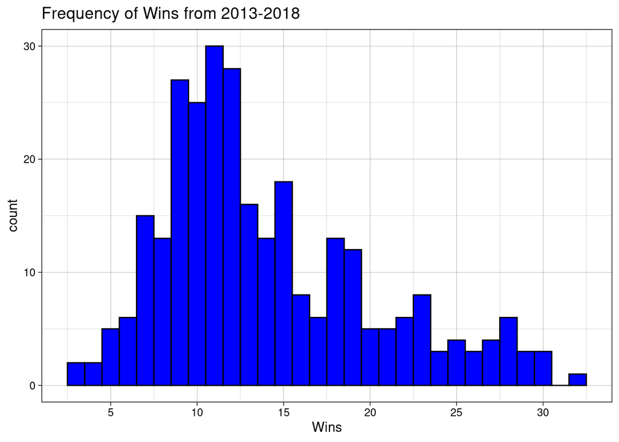

```r
# histogram visualizing a representation of the frequency of wins from 2013-2018 (Arham)

ggplot(data = BigDatasetFinal, aes(x = Wins)) + geom_histogram(fill = "blue", color = "black") + labs(title = "Frequency of Wins from 2013-2018") + theme_linedraw() + scale_x_continuous(breaks = seq(0, 35, 5))
```

**For our first visualization, we used a ggplot to create a histogram to graph the frequency of wins in 2013-2018. Observing the graph, it can be noted that most teams fall around the 10 win frequency, with the count being approximately 25 for 10 wins specifically. We also found that there was somewhat of an outlier at the end of the graph, with over 30 wins. The graph appears to be skewed to the right, showing that most teams are distributed under 15 wins.**

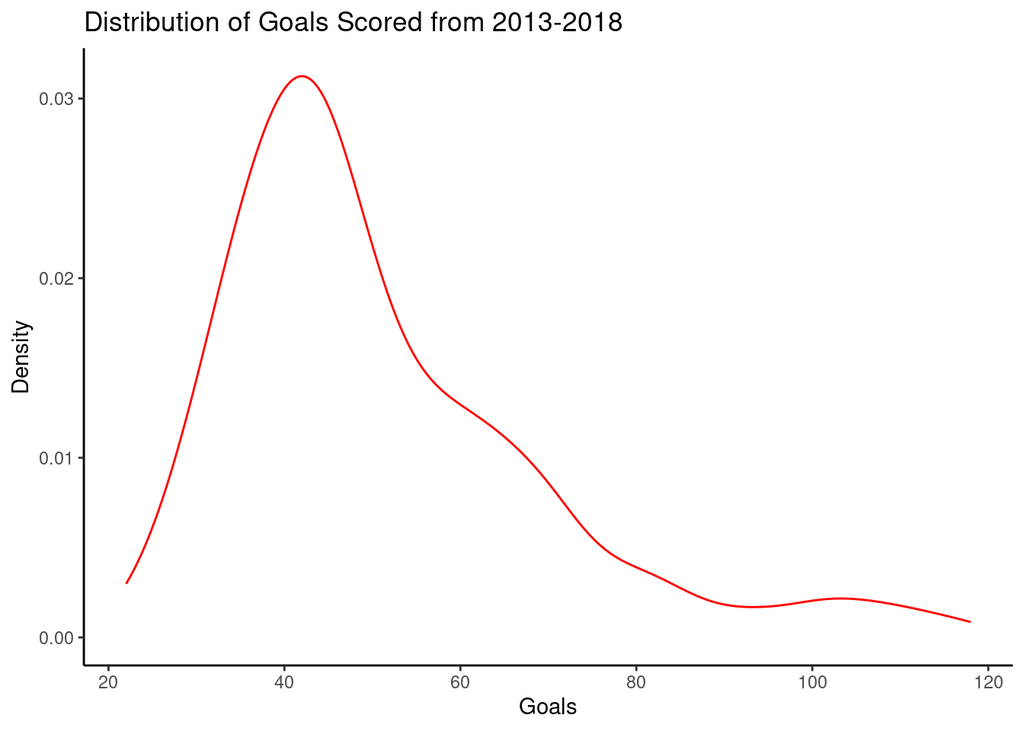

```r
#ggplot showing the distribution of goals scored from 2013-2018; https://stackoverflow.com/questions/63346308/interpreting-density-scale-geom-density (Arham)

ggplot(data = BigDatasetFinal, aes(x = GoalsFor)) + geom_density(color = "red") + theme_classic() + labs(title = "Distribution of Goals Scored from 2013-2018", x = "Goals", y = "Density") + scale_x_continuous(breaks = seq(0, 120, 20))
```

**For our other one variable visualization, we used a ggplot to create a density plot which maps the frequency of Goals scored through the years 2013-2018. We observed that most teams fall under the 40 goal range, with a kernel density estimation value of 0.03, which is significantly higher compared to the values for other Goal counts.**

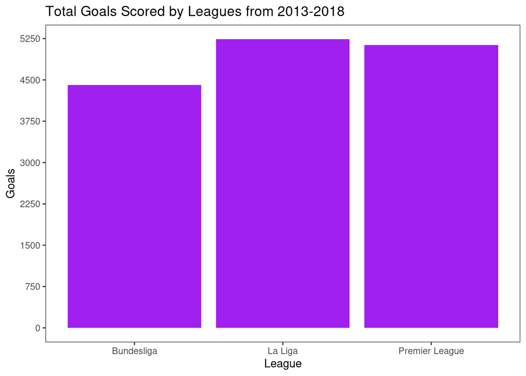

```r
#creates ggplot showing the total goals scored by leagues from 2013-2018 (Malik)

ggplot(data = BigDatasetFinal, aes(x = League, y = GoalsFor)) + geom_bar(stat = "identity", fill = "purple") + theme_test() + scale_y_continuous(breaks = seq(0, 5250, 750)) + labs(title = "Total Goals Scored by Leagues from 2013-2018", y = "Goals")
```

**For our first two variable visualization, we decided to compare the total number of goals scored by league. After constructing a ggplot to create a bargraph, the visualization depicts La Liga as the league that scored the most goals from 2013-2018 with approximately 5250. There isn’t a significant difference in the total number of goals scored between La Liga and Premier League. However, it appears that Bundesliga is clearly behind the other two leagues in total number of goals scored, being right below the 4500 goal count.**

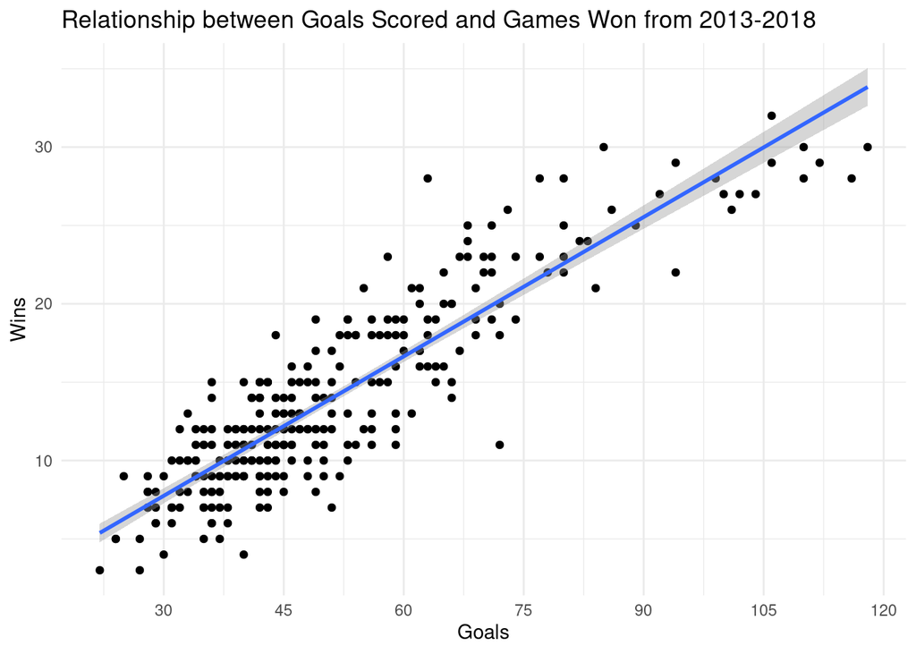

```r
# Creates visualization showing the relationship between goals and games won from 2013-2018 (Malik)

ggplot(data = BigDatasetFinal, aes(x = GoalsFor, y = Wins)) + geom_point() + geom_smooth(method = "lm") + theme_minimal() + labs(title = "Relationship between Goals Scored and Games Won from 2013-2018", x = "Goals") + scale_x_continuous(breaks = seq(0, 120, 15))
```

**For our second two variable visualization, we used a ggplot to create a scatterplot to observe the correlation between goals scored and games won from 2013-2018. We found that there is a positive correlation between these two variables as the more goals a team scored, the more games they won. We added a linear regression line to highlight this trend of the scatterplot.**

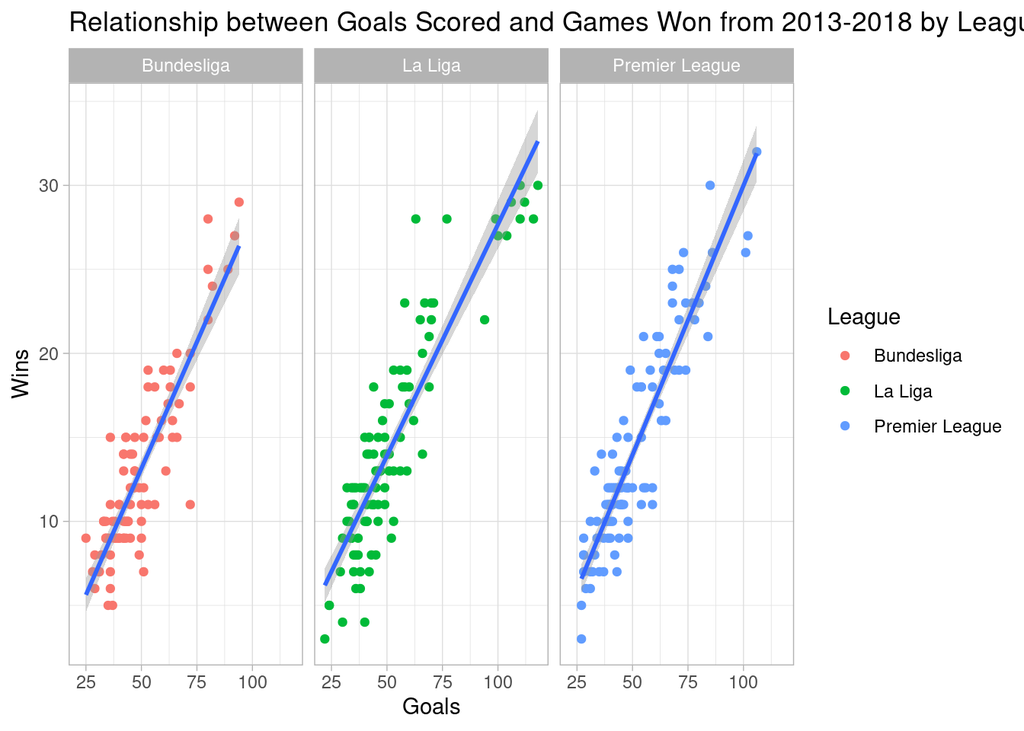

```r
# creates visualization depicting the relationship between goals and games won from 2013-2018 by league (Kevin)

ggplot(data = BigDatasetFinal, aes(x = GoalsFor, y = Wins)) + geom_point(aes(color = League)) + facet_grid(~League) + geom_smooth(method = "lm") + labs(title = "Relationship between Goals Scored and Games Won from 2013-2018 by League", x = "Goals") + scale_x_continuous(breaks = seq(0, 120, 25)) + theme_light()
```

**Similar to our second two variable visualization, our first three variable visualization considers the relationship between goals scored and games won from 2013-2018 but this time, we added a third variable, League. We thought it would be interesting to see whether all leagues have a similar slope or if some leagues don’t carry a strong association between goals scored and games won. Upon adding a linear regression line, we perceived that all three leagues have a similar slope, therefore, the league does not have a significant impact on the relationship between goals and wins.**

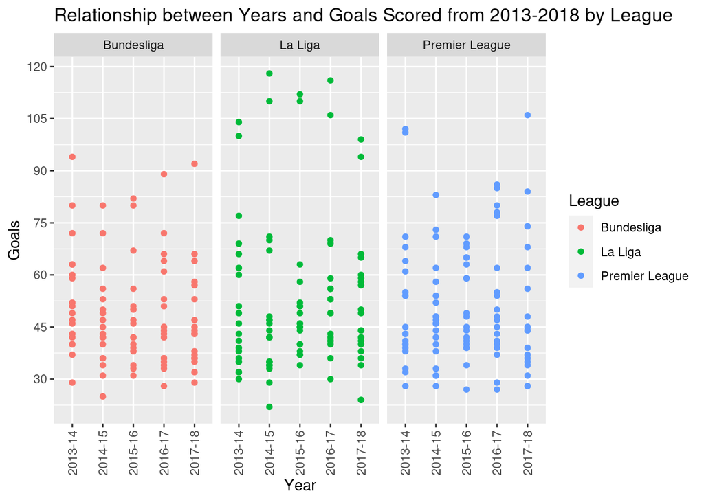

```r
#creates visualization depicting the relationship between Year and Goals Scored from 2013-2018 by league (Kevin)

ggplot(data = BigDatasetFinal, aes(x = Year, y = GoalsFor)) + geom_point(aes(color = League)) + facet_grid(~League) + geom_smooth(method = "lm") + labs(title = "Relationship between Years and Goals Scored from 2013-2018 by League", x = "Year", y = "Goals") + theme_gray() + theme(axis.text.x = element_text(angle = 90, vjust = 0.5, hjust=1)) + scale_y_continuous(breaks = seq(0, 150, 15))
```

**For our final three variable visualization, we decided to take year into account and see if it would have an impact on how many goals were scored. We hypothesized that because the sport was evolving, team’s goal scoring abilities would also be higher. Upon creating a ggplot to create a scatterplot, we measured the impact of year on the goals scored by league. We came to the conclusion that any year from 2013-2018 did not have a significant impact on the amount of goals scored for any league. The data points seem to vary from year to year and don’t appear to consistently change over the 5 year period of time.**